# U.S. Presidents and History

# **From George Washington to Donald Trump**

# **A close look into the Presidents’ Inaugural speeches and it’s connection to history**

The inauguration is considered as one of the most important moments for U.S. Presidents. The newly elected president will be inducted into the president’s position. The inaugural speech is the first official speech delivered by the president. In this project, I have applied texting mining techniques to 58 inaugural speeches to explore the themes and concentration during their inauguration speech, and study the relation with historic events.

```r
###install packages needed
packages.used=c("wordcloud","tidytext","rvest", "tibble", "qdap",
                "sentimentr", "gplots", "dplyr",
                "tm", "syuzhet", "factoextra", "scales", "RColorBrewer",
                "RANN", "topicmodels")
# check packages that need to be installed.
packages.needed=setdiff(packages.used,
                        intersect(installed.packages()[,1],
                                  packages.used))
# install additional packages
if(length(packages.needed)>0){
  install.packages(packages.needed, dependencies = TRUE, repos = "http://cran.us.r-project.org")
}
# load packages
library("rvest")
library("sentimentr")
library("qdap")
library("tibble")
library("gplots")
library("syuzhet")
library("factoextra")
library("scales")
library("dplyr")
library("tm")
library("RColorBrewer")
library("RANN")
library("wordcloud")
library("tidytext")
```

# Step 1: read the inaugural speeches data

|  | links | urls |
| --- | --- | --- |
| 1 | April 30, 1789 | http://www.presidency.ucsb.edu/ws/index.php?pid=25800 |
| 2 | March 4, 1793 | http://www.presidency.ucsb.edu/ws/index.php?pid=25801 |
| 3 | March 4, 1797 | http://www.presidency.ucsb.edu/ws/index.php?pid=25802 |
| 4 | March 4, 1801 | http://www.presidency.ucsb.edu/ws/index.php?pid=25803 |
| 5 | March 4, 1805 | http://www.presidency.ucsb.edu/ws/index.php?pid=25804 |
| 6 | March 4, 1809 | http://www.presidency.ucsb.edu/ws/index.php?pid=25805 |
| 7 | March 4, 1813 | http://www.presidency.ucsb.edu/ws/index.php?pid=25806 |
| 8 | March 4, 1817 | http://www.presidency.ucsb.edu/ws/index.php?pid=25807 |
| 9 | March 4, 1821 | http://www.presidency.ucsb.edu/ws/index.php?pid=25808 |
| 10 | March 4, 1825 | http://www.presidency.ucsb.edu/ws/index.php?pid=25809 |

[output cut: 48 more lines]

# Step 2 - text processing & overall WordCloud

Before starting to analyze the text, I want to modify the content of the inaugural speeches texts, by coverting upper-case characters in a character vector to lower-case, removing extra white space, english stopwords, empty words and punctuation. Then construct a term-document Matrix to analyze the overall wordcloud over the 58 inaugural speeches given by the 45 presidents in the U.S. history.

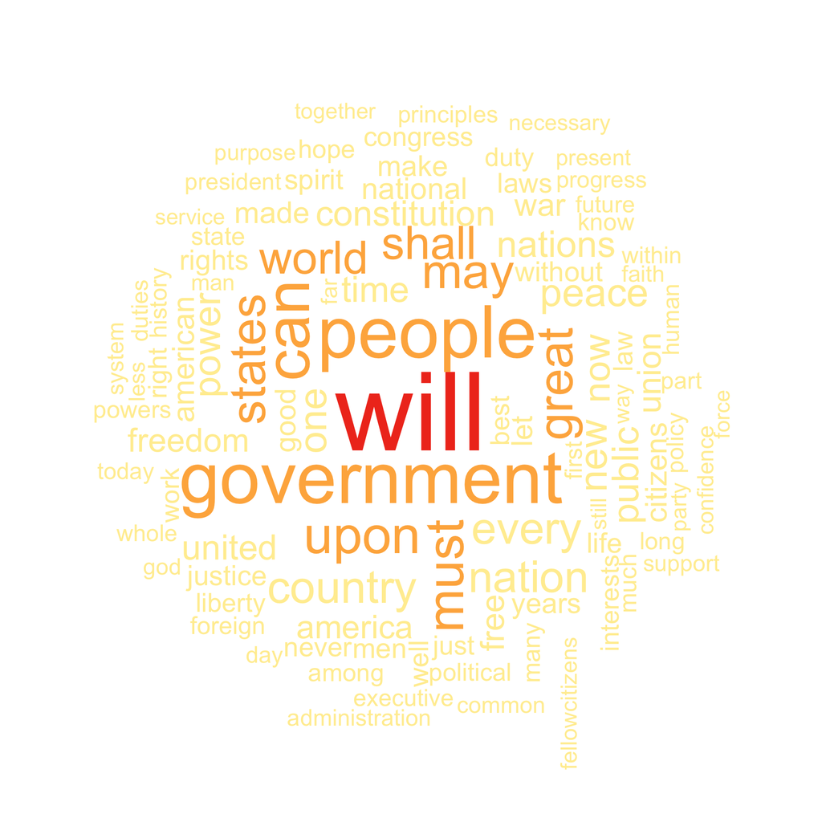

```r
file  <-tm_map(file, content_transformer(tolower))
file  <-tm_map(file, stripWhitespace)
file  <-tm_map(file, removeWords, stopwords("english"))
file  <-tm_map(file, removeWords, character(0))
file  <-tm_map(file, removePunctuation)
tdm.all<-TermDocumentMatrix(file)
tdm.tidy=tidy(tdm.all)
tdm.overall=summarise(group_by(tdm.tidy, term), sum(count))
wordcloud(tdm.overall$term, tdm.overall$`sum(count)`,
          scale=c(8,1),
          max.words=100,
          min.freq=1,
          random.order=FALSE,
          rot.per=0.3,
          use.r.layout=T,
          random.color=FALSE,
          colors=brewer.pal(3,"YlOrRd"))
```

We can see that the most frequently used words in presidents’ inaugural speeches are “Government”, “states”, “people”, “world” and “will”, “shall”, “must”, “can”. Given that the inaugural speech represents the very begining of the president’s term of office and delivers to the whole nation, most presidents tended to reiterate and emphasize the core values related to the country and discussed the topics related to “government”, “states” and “people”. In addition, they expressed their determinations and willingness in solving the issues people were concerned about, by using the words like “will”, “shall” and “must”. The wordcloud reveals 100 words, and we can easily to conclude that most of them are the frequently used words in public speeches.

Next, I’m interested in the concentration and emphasis of individual president’s speeches over different periods of the history and the connections with the significant historical events. I chose the five most representative prisidents in the history, George Washington (1789-1797), Abraham Lincoln(1861–1865), Franklin D. Roosevelt(1933–1945), John F. Kennedy(1961–1963), George W. Bush(2001-2009) from the list and analyzed their wordcloud seperately.

# Step 3 Individual presidnt’s WordCloud

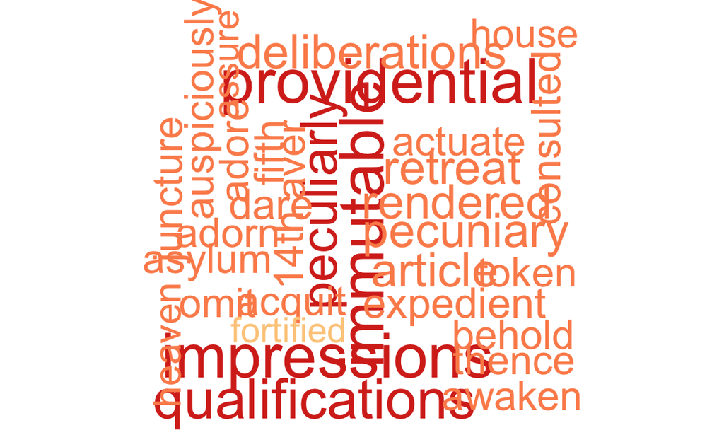

```r
file.1 <-Corpus(VectorSource(unlist(text.file)))
file.1 <-tm_map(file.1, stripWhitespace)
file.1 <-tm_map(file.1, content_transformer(tolower))
file.1 <-tm_map(file.1, removeWords, stopwords("english"))
file.1 <-tm_map(file.1, removeWords, character(0))
file.1 <-tm_map(file.1, removePunctuation)
dtm.1  <-DocumentTermMatrix(file.1,
                            control = list(weighting =function(x)
                              weightTfIdf(x, normalize =FALSE),
                              stopwords = TRUE))
ff.dtm.1 <- tidy(dtm.1)
### President George Washington
wordcloud(ff.dtm.1$term[ff.dtm.1$document==1],
          ff.dtm.1$count[ff.dtm.1$document==1],
          scale=c(3 ,0.4), min.freq=1, max.words= 80,
          random.order=FALSE, random.color = FALSE,
          rot.per=0.2, colors=brewer.pal(4, "OrRd"))
```

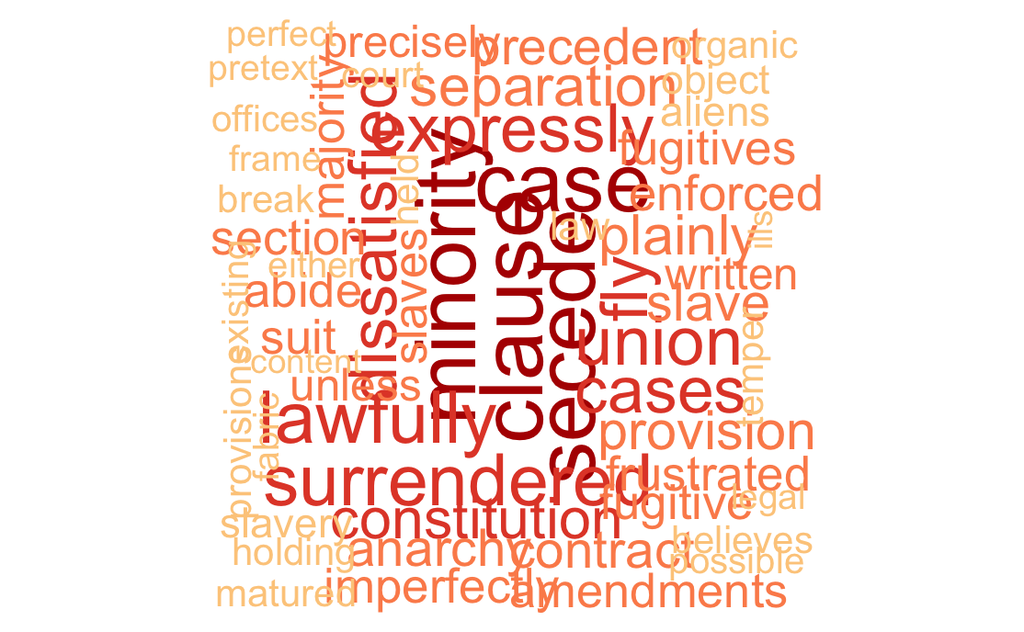

```r
### President Abraham Lincoln
wordcloud(ff.dtm.1$term[ff.dtm.1$document==19],
          ff.dtm.1$count[ff.dtm.1$document==19],
          scale=c(3 ,0.4), min.freq=1, max.words= 80,
          random.order=FALSE, random.color = FALSE,
          rot.per=0.2, colors=brewer.pal(5, "OrRd"))
```

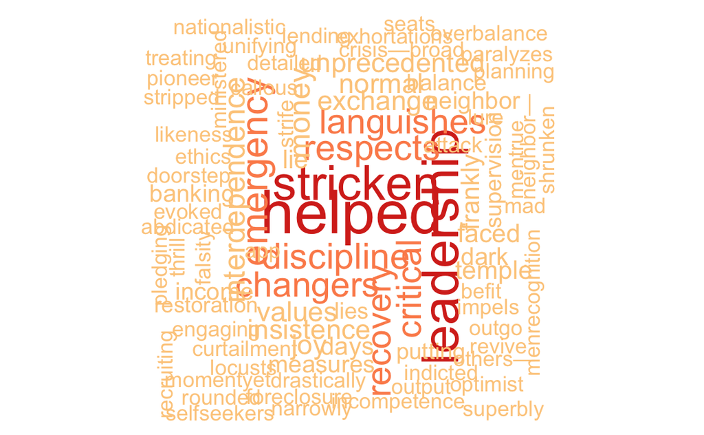

```r
### President Franklin D. Roosevelt
wordcloud(ff.dtm.1$term[ff.dtm.1$document==37&38&39&40],
          ff.dtm.1$count[ff.dtm.1$document==37&38&39&40],
          scale=c(3 ,0.4),min.freq=1, max.words= 100,
          random.order=FALSE, random.color = FALSE,
          rot.per=0.2, colors=brewer.pal(4, "OrRd"))
```

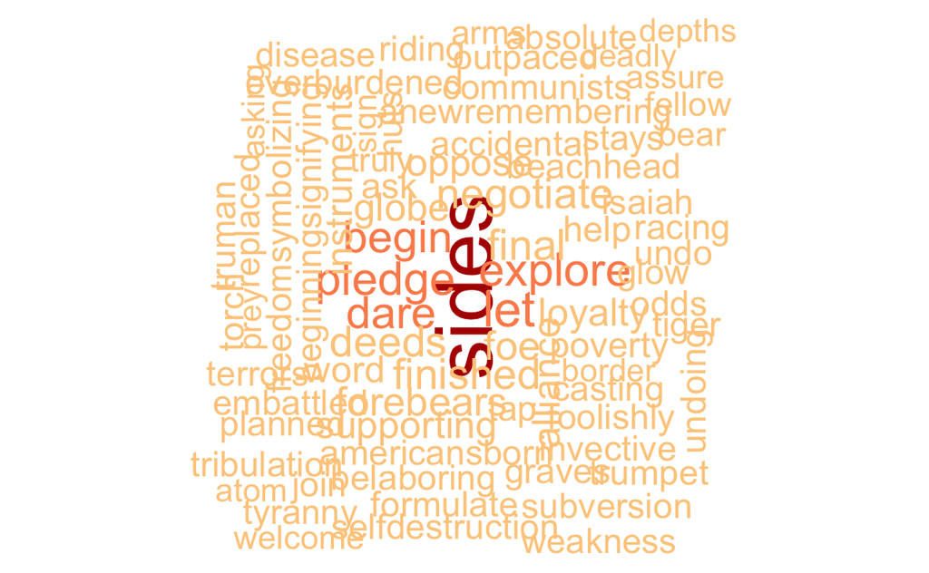

```r
### President John F. Kennedy
wordcloud(ff.dtm.1$term[ff.dtm.1$document==44],
          ff.dtm.1$count[ff.dtm.1$document==44],
          scale=c(3 ,0.7), min.freq=1, max.words= 80,
          random.order=FALSE, random.color = FALSE,
          rot.per=0.2, colors=brewer.pal(5, "OrRd"))
```

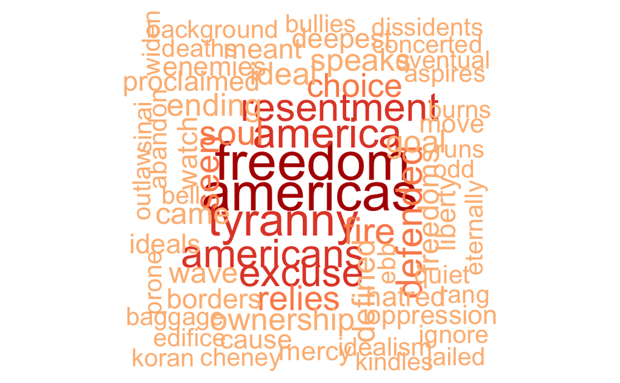

```r
### President George W. Bush
wordcloud(ff.dtm.1$term[ff.dtm.1$document==55 ],ff.dtm.1$count[ff.dtm.1$document==55 ],
          scale=c(3 ,0.6), min.freq=1, max.words= 100,
          random.order=FALSE, random.color = FALSE,
          rot.per=0.2, colors=brewer.pal(6, "OrRd"))
```

The next one is president John F. Kennedy. The core keyword in his speech was “side”, which resonates with the history of the Cold War. The high tension between the Soviet Union and the U.S. drove him to put lots of emphasis on the topic of “pledge”, “alliance” and “oppose”. In the history, he was involved in several major events most famously the Cuban Missile Crisis which threatened nuclear war between U.S. and the Soviet Union.

The last one is the president George W. Bush, who led the America go through the September 11 terrorist attacks in his first term. As a response to terrorists, he launched the famous “War on Terror” (an international mility campaign) including the war in Afghanistan in 2001 and Iraq in 2003. In his speech of the re-election, he talked about the american spirit and core values like “freedom”, “soul” and against “tyranny”.

Those individual speeches show that the history, in another words, the domestic and international situation has an impact on president’s inaugural speeches and the following decision-makings in his term. In turn, president’s decision-making would also influence the history.

# Step 4 interactive WordCloud between different presidents

Furthermore, I would also like to see if the speech contents from two different presidents would vary a lot given they are from totally different historical backgrounds. I applied the TF-IDF weighted document-term matrices for individual speeches to identify the the most relevant and important words and interactively mapping the important words between two presidents in wordcloud within a web application by using Shiny-package.

```r
file   <- Corpus(DirSource(folder.path))
dtm <- DocumentTermMatrix(file,
                          control = list(weighting = function(x)
                                        weightTfIdf(x, normalize =FALSE),
                                         stopwords = TRUE))
ff.dtm=tidy(dtm)
library(shiny)
shinyApp(ui = fluidPage(
      fluidRow(style = "padding-bottom: 20px;",
        column(4, selectInput('speech1', 'Speech 1',
                              speeches,
                              selected=speeches[5])),
        column(4, selectInput('speech2', 'Speech 2', speeches,
                              selected=speeches[9])),
        column(4, sliderInput('nwords', 'Number of words', 3,
                               min = 20, max = 200, value=100, step = 20))
      ),
      fluidRow(
        plotOutput('wordclouds', height = "400px")
      )
    ),
    server = function(input, output, session) {
      # Combine the selected variables into a new data frame
      selectedData <- reactive({
        list(dtm.term1=ff.dtm$term[ff.dtm$document==as.character(input$speech1)],
             dtm.count1=ff.dtm$count[ff.dtm$document==as.character(input$speech1)],
             dtm.term2=ff.dtm$term[ff.dtm$document==as.character(input$speech2)],
             dtm.count2=ff.dtm$count[ff.dtm$document==as.character(input$speech2)])

      })
      output$wordclouds <- renderPlot(height = 400, {
        par(mfrow=c(1,2), mar = c(0, 0, 3, 0))
        wordcloud(selectedData()$dtm.term1,
                  selectedData()$dtm.count1,
              scale=c(4,0.5),
              max.words=input$nwords,
              min.freq=1,
              random.order=FALSE,
              rot.per=0,
              use.r.layout=FALSE,
              random.color=FALSE,
              colors=brewer.pal(10,"Blues"),
            main=input$speech1)
        wordcloud(selectedData()$dtm.term2,
                  selectedData()$dtm.count2,
              scale=c(4,0.5),
              max.words=input$nwords,
              min.freq=1,
              random.order=FALSE,
              rot.per=0,
              use.r.layout=FALSE,
              random.color=FALSE,
              colors=brewer.pal(10,"Blues"),
            main=input$speech2)
      })
    },
    options = list(height = 600)
)
```

```
Listening on http://127.0.0.1:7720
```

# Step 5 Sentimental Analysis

The next step is to analysis whether the presidents’ emotions revealed in their inaugural speeches have some association with historical events. For example, during the Great Depression, World War II or Civil War, were the presidents during those periods having some negative emotions. What was the dominate emotion during their speeches?

The way is to use sentences as units of analysis, given sentences are natural languge units for organizing thoughts and ideas. For each extracted sentence, I will apply sentiment analysis using NRC sentiment lexion which is a list of English words and the associations with eight basic emotions (anger, fear, anticipation, trust, surprise, sadness, joy, and disgust) and two sentiments (negative and positive).

```r
## President BarackObama
par(mar=c(4, 6, 2, 1))
emo.means=colMeans(select(sentence.list[sentence.list$President == "Barack Obama", ], anger:trust)>0.01)
col.use= brewer.pal(2, "OrRd")
```

```
minimal value for n is 3, returning requested palette with 3 different levels
```

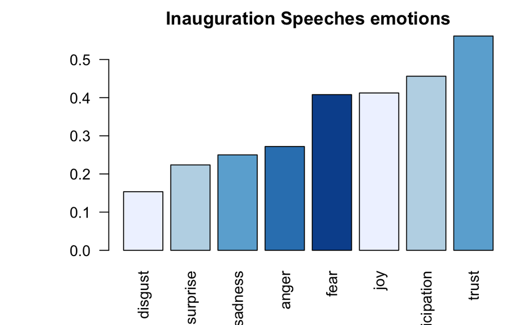

```r
barplot(emo.means[order(emo.means)], las=2, col=brewer.pal(5, "Blues"), horiz=F, main="Inauguration Speeches emotions")
## President Abraham Lincolm
par(mar=c(4, 6, 2, 1))
```

```r
emo.means=colMeans(select(sentence.list[sentence.list$President == "Abraham Lincoln", ], anger:trust)>0.01)
col.use= brewer.pal(2, "OrRd")
```

```
minimal value for n is 3, returning requested palette with 3 different levels
```

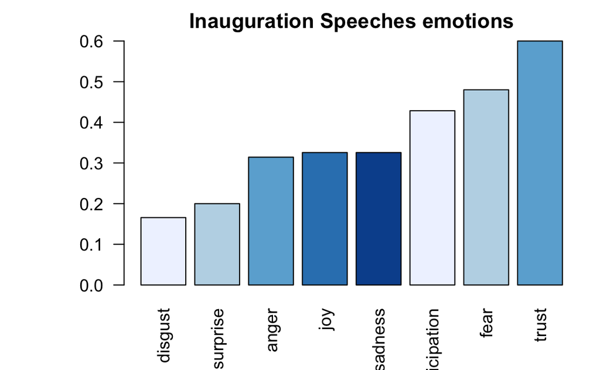

```r
barplot(emo.means[order(emo.means)], las=2, col=brewer.pal(5, "Blues"), horiz=F, main="Inauguration Speeches emotions")
## President RonaldReagan
par(mar=c(4, 6, 2, 1))
```

```r
emo.means=colMeans(select(sentence.list[sentence.list$President == "Ronald Reagan", ], anger:trust)>0.01)
col.use= brewer.pal(2, "OrRd")
```

```
minimal value for n is 3, returning requested palette with 3 different levels
```

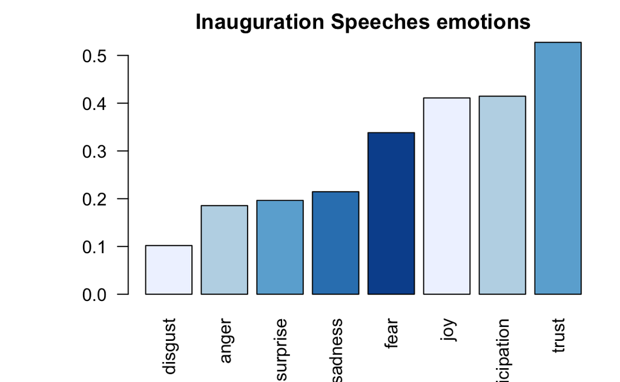

```r
barplot(emo.means[order(emo.means)], las=2, col=brewer.pal(5, "Blues"), horiz=F, main="Inauguration Speeches emotions")
```

In conclusion, the presidents’ inaugural speeches are closely related to the relevant history and important historical events, both in the contents and sentiments. I think if we could also collect data(speeches) that were taken during their terms, more forms of connections can be revealed.